# Longitudinal Survey 4 Planform Complexity

Oliver Franklin & Nicci Zargarpour

2025-12-15

Planform complexity metrics are useful for comparing aspects of stream condition and habitat heterogeneity. Because these metrics are typically expressed at the level of the reach, to make statistical inferences one would require a sample of numerous reaches and/or numerous years. If you have access to such data, a mixed-effects model would be a suitable approach that accounts for the correlation between repeated measurements at each reach. We have not included these tests in this script, but we hope in future to include this in scripts focused on analysing time-series of data.

In general, we feel that visualisations and summary statistics can provide sufficient information to interpret whether your restoration project had the intended influence with regards to planform complexity. Changes in planform complexity are often conspicuous and may be associated with lower-frequency events. As such, your strongest support for your project may come from recognition of a trend in a metric over time (rather than an individual episode), that is not evident in your control/reference reach.

For this script we will import the tidied dataframe, which was exported to your output folder in the Data Wrangling script.

We now need to you to provide some GPS coordinates in the below code chunk. For each year at each reach, you will enter the x,y coordinates (in decimal degrees) of the downstream/first thalweg measurments and of the upstream/final thalweg measurements. Data is entered in vectors of equal length and following the same sequence. Check the table and map that are generated to ensure the data is entered correctly.

```r
# update the below rows so that they correspond to your site(s), year(s), and GPS lat/long for both start and end of thalweg measurements. You can add or remove entries within the list in brackets if you have more/fewer sites and years
constants_df <- data.frame(
  Site = c("Hatchery Channel", "Hatchery Channel", "Brousseau Channel", "Brousseau Channel"),  # Edit / Add your site names
  year = c(2024, 2025, 2024, 2025),  # Corresponding years for each site
  GPSstart_lat = c(18.107629, 18.107644, 51.57816, 51.57814), # latitude (x value) of 1st (downstream) thalweg measurement at each site-year
  GPSstart_lon = c(-89.813950, -89.813954, -1.56655, -1.56656), # longitude (y value) of 1st (downstream) thalweg measurement at each site-year
  GPSend_lat = c(18.108429, 18.108433, 51.57733, 51.57732), # latitude (x value) of last (upstream) thalweg measurement at each site-year
  GPSend_lon = c(-89.814509, -89.814500, -1.56686, -1.56684) # longitude (y value) of last (upstream) thalweg measurement at each site-year
)
```

```
##                Site year GPSstart_lat GPSstart_lon GPSend_lat GPSend_lon
## 1  Hatchery Channel 2024     18.10763    -89.81395   18.10843  -89.81451
## 2  Hatchery Channel 2025     18.10764    -89.81395   18.10843  -89.81450
## 3 Brousseau Channel 2024     51.57816     -1.56655   51.57733   -1.56686
## 4 Brousseau Channel 2025     51.57814     -1.56656   51.57732   -1.56684
```

[interactive chart not shown]

# Sinuosity

Sinuosity is calculated by dividing the thalweg line length by the straight-line distance between the start and end points of the thalweg longitudinal survey. This is based on Rosgen (1994), but using the thalweg:stream length ratio, rather than the stream length:valley length ratio. The metric used here has been applied widely (e.g., Roni et al 2024), but is distinct from Rosgen’s. We generate here (and export to your output folder) a table of sinuosity and a simple figure to illustrate change over time.

|  | Site | year | Straight_Line_Distance | Thalweg_Line_Length | Sinuosity |
| --- | --- | --- | --- | --- | --- |
| 1 | Hatchery Channel | 2024 | 106.9069708419876 | 143 | 1.337611559599414 |
| 2 | Hatchery Channel | 2025 | 105.1269930026692 | 143 | 1.360259586197516 |
| 3 | Brousseau Channel | 2024 | 94.85139756679779 | 144 | 1.518164241054962 |
| 4 | Brousseau Channel | 2025 | 93.3145760066308 | 144 | 1.543167275279347 |

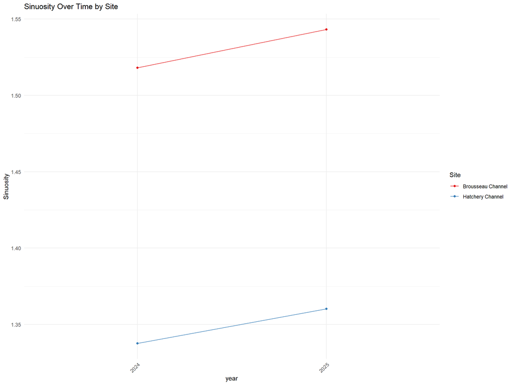

# Nodes

Here we generate some metrics relating to the nodes that were observed in the field. By node, we mean any confluence or bifurcation from the focal channel, with the subordinate channel being separated from the focal channel by an island (area above bankfull elevation). We limited the information that we collected on nodes in the field for logistical reasons, but one could go further and count the nodes of subordinate channels, measure lengths of side channels etc. Our data are limited to nodes that are observable from the focal channel.

|  | Site | year | node_count | node_density | proportion_confluent | proportion_wetted |
| --- | --- | --- | --- | --- | --- | --- |
| 1 | Hatchery Channel | 2024 | 0 | 0 | 0 | 0 |
| 2 | Brousseau Channel | 2024 | 0 | 0 | 0 | 0 |
| 3 | Hatchery Channel | 2025 | 0 | 0 | 0 | 0 |
| 4 | Brousseau Channel | 2025 | 0 | 0 | 0 | 0 |

The table above provides some metrics that may be of interest if the restoration objectives include an alteration to the branching density or pattern of the stream (e.g., see Stefankiv et al 2019). Number and density of nodes may represent floodplain habitat area or aquatic complexity, and would be greater in anastomosing channels than more channelised reaches.

Depending on the nature of the system, it may also be of interest to investigate the proportion of nodes that are confluences versus bifurcations, or the proportion that are wetted during periods of low flow / survey timing. Remember that wetted proportion is flow-dependent and comparisons among years/reaches may not be valid without quantitative flow information or well-matched reference sites.

# River Complexity Index

The River Complexity Index (RCI) represents a distinct aspect of variability that is not captured with a thalweg profile, and is based on both sinuosity and node density (Brown 2002). The formula we use is:

$RCI = \dfrac{T*(1+J)}{S^2}*100$

where **T** = thalweg line length, **J** = number of nodes on the main channel, and **S** = single straight line distance along the reach.

Note that the above formula differs from that proposed by Brown (2002) as, for a given sinuosity value, our approach ‘penalises’ longer reaches by assigning a lower RCI (which is consistent with recent restoration literature, e.g. Roni et al 2024). The penalisation of longer reaches is intended to reflect the fact that over longer distances streams have more opportunities for complexity due to (e.g.) varying substrate types, slopes, tributaries, constraining features. Although the intention for restoration effectiveness monitoring is to compare near-identical control/reference sites, this approach recognises that sometimes the best available reference site may differ in length.

The RCI increases in value with complexity as more sinuosity and/or a greater number of nodes are present. The intention is to compare RCI among your sites and across time, and with other streams that have collected data following our methods. It is important to note that differences in data collection approaches can preclude comparisons among RCI from different studies. For example, we count nodes only along the focal channel, and we use straight line length to standardise reach length (contrasting to the use of stream centreline in Roni et al. 2024).

|  | Site | year | node_count | node_density | proportion_confluent | proportion_wetted | Sinuosity | RCI |
| --- | --- | --- | --- | --- | --- | --- | --- | --- |
| 1 | Hatchery Channel | 2024 | 0 |  |  |  | 1.337611559599414 | 1.251192086974808 |
| 2 | Brousseau Channel | 2024 | 0 |  |  |  | 1.518164241054962 | 1.600571293623603 |
| 3 | Hatchery Channel | 2025 | 0 |  |  |  | 1.360259586197516 | 1.293920378910656 |
| 4 | Brousseau Channel | 2025 | 0 |  |  |  | 1.543167275279347 | 1.653725860759086 |

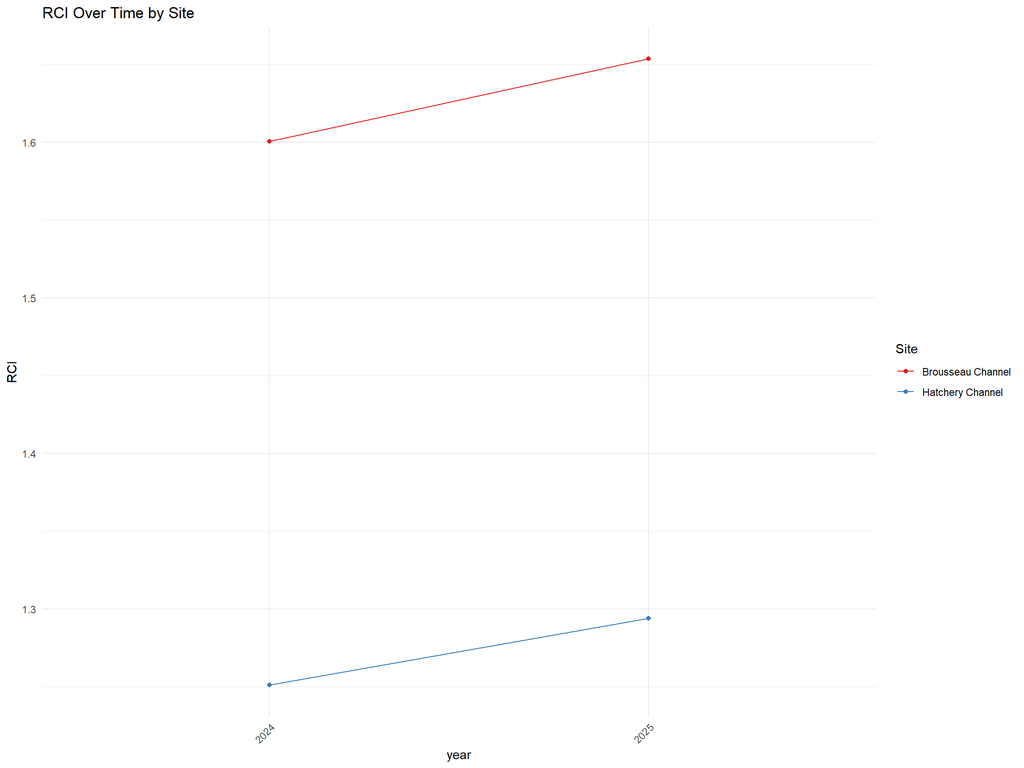

# References

Brown, A. G. 2002. Learning from the past: paleohydrology and paleoecology. Freshwater Biology 47:817–829

Roni, P., Burgess, S., Ross, K., Clark, C., Kvistad, J., Krall, M., Camp, R., Arams, A. and Camp, M.J., 2024. Evaluation of floodplain restoration projects in the interior Columbia River basin using a combination of remote sensing and field data. Canadian Journal of Fisheries and Aquatic Sciences, (ja).

Rosgen, D.L., 1994. A classification of natural rivers. Catena, 22(3), pp.169-199.

Stefankiv, O., T. J. Beechie, J. E. Hall, G. R. Pess, and B. Timpane-Padgham. 2019. Influences of valley form and land use on large river and floodplain habitats in Puget Sound. River Research and Applications 35(2):133–145